# Tugas Pertemuan 3

Mhd Haekal Hakim

2025-09-17

# Import Data

```r
data <- read.csv("C:/Users/mhdha/Downloads/NewDelhi_Air_quality.csv")
str(data)
```

```
## 'data.frame':    72 obs. of  12 variables:
##  $ X              : int  1 2 3 4 5 6 7 8 9 10 ...
##  $ AQI            : num  30.2 28.2 26.6 25 26 26 26 24 23 24 ...
##  $ CO             : num  199 198 199 202 205 ...
##  $ datetime       : chr  "2022-10-21:18" "2022-10-21:19" "2022-10-21:20" "2022-10-21:21" ...
##  $ no2            : num  0.0469 0.0465 0.0469 0.0482 0.0489 ...
##  $ o3             : num  55.8 54.9 54.6 55.1 55.8 ...
##  $ pm10           : num  10.5 10.7 11.2 11.1 10.4 ...
##  $ pm25           : num  5.64 4.62 3.52 2.23 1.98 ...
##  $ so2            : num  0.387 0.41 0.402 0.376 0.339 ...
##  $ timestamp_local: chr  "2022-10-21T23:00:00" "2022-10-22T00:00:00" "2022-10-22T01:00:00" "2022-10-22T02:00:00" ...
##  $ timestamp_utc  : chr  "2022-10-21T18:00:00" "2022-10-21T19:00:00" "2022-10-21T20:00:00" "2022-10-21T21:00:00" ...
##  $ ts             : int  1666375200 1666378800 1666382400 1666386000 1666389600 1666393200 1666396800 1666400400 1666404000 1666407600 ...
```

```r
data
```

```
##     X  AQI       CO      datetime        no2       o3      pm10     pm25
## 1   1 30.2 198.6027 2022-10-21:18 0.04685717 55.78995 10.486722 5.637410
## 2   2 28.2 197.6013 2022-10-21:19 0.04645554 54.93164 10.719325 4.618169
## 3   3 26.6 198.6027 2022-10-21:20 0.04685717 54.64554 11.155578 3.520902
## 4   4 25.0 201.9405 2022-10-21:21 0.04819594 55.07469 11.116206 2.225919
## 5   5 26.0 205.2784 2022-10-21:22 0.04886533 55.78995 10.405250 1.979471
## 6   6 26.0 208.6163 2022-10-21:23 0.05020411 56.50520  9.402518 1.792677
## 7   7 26.0 208.6163 2022-10-22:00 0.05020411 55.78995  8.482822 1.752237
## 8   8 24.0 205.2784 2022-10-22:01 0.05020411 52.92892  7.586667 1.858459
## 9   9 23.0 200.2716 2022-10-22:02 0.04685717 50.06790  7.636587 2.208076
## 10 10 24.0 196.9338 2022-10-22:03 0.04417961 51.49841  8.487648 2.476681
## 11 11 25.0 198.6027 2022-10-22:04 0.04284084 53.64418  9.357371 2.585729
## 12 12 26.0 200.2716 2022-10-22:05 0.04049798 55.78995 10.338728 2.390081
## 13 13 27.0 203.6095 2022-10-22:06 0.04016329 59.36623 10.523314 2.086022
## 14 14 29.0 205.2784 2022-10-22:07 0.03882451 62.22725 10.635970 1.937047
```

[output cut: 131 more lines]

```r
# Mengubah nama variabel agar mudah untuk diolah
names(data)[names(data) == "AQI"] <- "Yt"
names(data)[names(data) == "pm25"]  <- "Xt"

# Menambahkan kolom t untuk periodenya
data$t <- 1:nrow(data)

# Menambahkan kolom Y(t-1)
data[["Y(t-1)"]] <- dplyr::lag(data$Yt)

# Membuat data baru dengan menggunakan variabel pm25 saja sebagai peubah x sesuai dengan perintah soal
data <- data[, c("t", "Yt", "Y(t-1)", "Xt")]
print(data)
```

```
##     t   Yt Y(t-1)       Xt
## 1   1 30.2     NA 5.637410
## 2   2 28.2   30.2 4.618169
## 3   3 26.6   28.2 3.520902
## 4   4 25.0   26.6 2.225919
## 5   5 26.0   25.0 1.979471
## 6   6 26.0   26.0 1.792677
## 7   7 26.0   26.0 1.752237
## 8   8 24.0   26.0 1.858459
## 9   9 23.0   24.0 2.208076
## 10 10 24.0   23.0 2.476681
## 11 11 25.0   24.0 2.585729
## 12 12 26.0   25.0 2.390081
## 13 13 27.0   26.0 2.086022
## 14 14 29.0   27.0 1.937047
```

[output cut: 58 more lines]

## Pembagian Data

```r
#Split Data untuk data train (80%) dan data test (20%),
train<-data[1:58,]
test<-data[59:72,]
```

```r
#data time series
train.ts<-ts(train)
test.ts<-ts(test)
data.ts<-ts(data)
```

- **distributed lag model** : Variabel Dependen Y dipengaruhi oleh lag dari variabel independen X ( Xt-1, Xt-2 , dst)
- **Autoregresive model** : Variabel Dependen Y dipengaruhi oleh lag dirinya sendiri (Yt-1, Yt-2, dst) dan X sekarang (Xt)

# Model Koyck

Model Koyck didasarkan pada asumsi bahwa semakin jauh jarak lag peubah independen dari periode sekarang maka semakin kecil pengaruh peubah lag terhadap peubah dependen.

Koyck mengusulkan suatu metode untuk menduga model dinamis distributed lag dengan mengasumsikan bahwa semua koefisien $\beta$ mempunyai tanda sama.

Model kyock merupakan jenis paling umum dari model infinite distributed lag dan juga dikenal sebagai geometric lag

$$y_t=a(1-\lambda)+\beta_0X_t+\beta_1Z_t+\lambda Y_{t-1}+V_t$$

dengan
$$V_t=u_t-\lambda
u_{t-1}$$

## Pemodelan

Pemodelan model Koyck dengan `R` dapat menggunakan `dLagM::koyckDlm()` . Fungsi umum dari `koyckDlm` adalah sebagai berikut.

```r
koyckDlm(x , y , intercept)
```

Fungsi `koyckDlm()` akan menerapkan model lag terdistribusi dengan transformasi Koyck satu prediktor. Nilai `x` dan `y` tidak perlu sebagai objek *time series* (`ts`). `intercept` dapat dibuat `TRUE` untuk memasukkan intersep ke dalam model.

```r
#MODEL KOYCK menggunakan fungsi koyckDlm()
model.koyck <- koyckDlm(x = train$Xt, y = train$Yt)
summary(model.koyck)
```

```
##
## Call:
## "Y ~ (Intercept) + Y.1 + X.t"
##
## Residuals:
##      Min       1Q   Median       3Q      Max
## -2.14443 -0.61319  0.03512  0.48195  2.18725
##
## Coefficients:
##             Estimate Std. Error t value Pr(>|t|)
## (Intercept)   4.0771     1.8299   2.228   0.0301 *
## Y.1           0.8897     0.0588  15.131   <2e-16 ***
## X.t          -0.5723     0.2854  -2.005   0.0500 *
## ---
## Signif. codes:  0 '***' 0.001 '**' 0.01 '*' 0.05 '.' 0.1 ' ' 1
##
## Residual standard error: 0.9279 on 54 degrees of freedom
## Multiple R-Squared: 0.8273,  Adjusted R-squared: 0.8209
## Wald test: 129.1 on 2 and 54 DF,  p-value: < 2.2e-16
##
## Diagnostic tests:
## NULL
##
##                             alpha       beta       phi
## Geometric coefficients:  36.94716 -0.5722988 0.8896496
```

```r
# Menghitung nilai AIC dan BIC untuk mengevaluasi model
AIC(model.koyck)
```

```
## [1] 158.1481
```

```r
BIC(model.koyck)
```

```
## [1] 166.3203
```

Dari hasil tersebut, didapat bahwa peubah $x_t$ dan $y_{t-1}$ memiliki nilai $P-Value<0.05$. Hal ini menunjukkan bahwa peubah $x_t$ dan $y_{t-1}$ berpengaruh signifikan terhadap $y$. Adapun model keseluruhannya adalah sebagai berikut

$$\hat{Y_t}=4.0771-0.5723X_t+0.8897Y_{t-1}$$

## Peramalan dan Akurasi

Berikut adalah hasil peramalan y untuk 14 periode kedepan menggunakan model koyck

```r
fore.koyck <- forecast(model = model.koyck, x=test$Xt, h=14)
fore.koyck
```

```
## $forecasts
##  [1] 22.96490 22.79987 22.60639 22.40415 22.24036 22.15991 22.16242 22.20757
##  [9] 22.27123 22.33380 22.39368 22.42982 22.44082 22.47014
##
## $call
## forecast.koyckDlm(model = model.koyck, x = test$Xt, h = 14)
##
## attr(,"class")
## [1] "forecast.koyckDlm" "dLagM"
```

```r
mape.koyck <- MAPE(fore.koyck$forecasts, test$Yt)
mape.koyck #data test
```

```
## [1] 0.1054825
```

```r
#akurasi data training
GoF(model.koyck)
```

```
##              n       MAE          MPE       MAPE      sMAPE     MASE       MSE
## model.koyck 57 0.6909776 -0.001122737 0.02589331 0.02582947 1.040181 0.8157075
##                  MRAE    GMRAE
## model.koyck 757377131 11372.75
```

# Regression with Distributed Lag

Pemodelan model Regression with Distributed Lag dengan `R` dapat menggunakan `dLagM::dlm()` . Fungsi umum dari `dlm` adalah sebagai berikut.

```r
dlm(formula , data , x , y , q , remove )
```

Fungsi `dlm()` akan menerapkan model lag terdistribusi dengan satu atau lebih prediktor. Nilai `x` dan `y` tidak perlu sebagai objek *time series* (`ts`). $q$ adalah integer yang mewakili panjang *lag* yang terbatas.

## Pemodelan (Lag=2)

```r
# nilai q berarti memasukkan pengaruh Xt ke 2 lag pertama
model.dlm <- dlm(x = train$Xt,y = train$Yt , q = 2)
summary(model.dlm)
```

```
##
## Call:
## lm(formula = model.formula, data = design)
##
## Residuals:
##     Min      1Q  Median      3Q     Max
## -4.5504 -1.2693 -0.0678  1.0780  4.0378
##
## Coefficients:
##             Estimate Std. Error t value Pr(>|t|)
## (Intercept)   35.453      1.656  21.405  < 2e-16 ***
## x.t           -8.438      2.173  -3.883 0.000293 ***
## x.1            6.515      3.189   2.043 0.046126 *
## x.2           -2.178      1.553  -1.403 0.166651
## ---
## Signif. codes:  0 '***' 0.001 '**' 0.01 '*' 0.05 '.' 0.1 ' ' 1
##
## Residual standard error: 1.84 on 52 degrees of freedom
## Multiple R-squared:  0.343,  Adjusted R-squared:  0.3051
## F-statistic: 9.048 on 3 and 52 DF,  p-value: 6.393e-05
##
## AIC and BIC values for the model:
##        AIC      BIC
## 1 233.0605 243.1873
```

```r
# Menghitung nilai AIC dan BIC untuk mengevaluasi kualitas model
AIC(model.dlm)
```

```
## [1] 233.0605
```

```r
BIC(model.dlm)
```

```
## [1] 243.1873
```

$$\hat{Y_t}=35.453-8.438X_t+6.515X_{t-1}-2.178X_{t-2}$$

## Peramalan dan Akurasi

Berikut merupakan hasil peramalan $y$ untuk 14 periode kedepan

```r
fore.dlm <- forecast(model = model.dlm, x=test$Xt, h=14)
fore.dlm
```

```
## $forecasts
##  [1] 23.68033 22.74314 23.03487 22.61281 23.01583 23.67989 24.09058 24.12849
##  [9] 24.26804 24.25165 24.33554 24.05758 23.95663 24.42047
##
## $call
## forecast.dlm(model = model.dlm, x = test$Xt, h = 14)
##
## attr(,"class")
## [1] "forecast.dlm" "dLagM"
```

```r
mape.dlm <- MAPE(fore.dlm$forecasts, test$Yt)
mape.dlm
```

```
## [1] 0.1271423
```

```r
#akurasi data training
GoF(model.dlm)
```

```
##            n      MAE          MPE       MAPE      sMAPE     MASE      MSE
## model.dlm 56 1.416706 -0.004142738 0.05191735 0.05183698 2.188732 3.143529
##                 MRAE    GMRAE
## model.dlm 6203778359 29920.77
```

## *Lag* Optimum

```r
#penentuan lag optimum
finiteDLMauto(formula = Yt ~ Xt,
              data = data.frame(train), q.min = 1, q.max = 10,
              model.type = "dlm", error.type = "AIC", trace = TRUE)
```

```
##    q - k    MASE      AIC      BIC    GMRAE   MBRAE R.Adj.Sq    Ljung-Box
## 10    10 1.72201 186.2653 210.5909 49688.22 0.71611  0.52879 1.423614e-08
## 9      9 1.85325 195.5979 218.2998 44081.17 0.73051  0.47894 5.052925e-09
## 8      8 1.88799 199.1205 220.1527 38823.62 0.66594  0.50264 2.075788e-10
## 7      7 1.84754 200.0655 219.3837 30520.82 0.62313  0.53206 5.330174e-10
## 6      6 1.73867 201.1051 218.6663 22650.85 0.56392  0.54223 4.524737e-10
## 5      5 1.75280 204.0813 219.8436 23085.14 1.65593  0.53463 6.980942e-10
## 4      4 1.85610 209.9314 223.8543 31881.26 0.72405  0.50086 2.767593e-09
## 3      3 2.13163 220.3167 232.3607 38604.33 0.77447  0.42645 1.445641e-09
## 2      2 2.18873 233.0605 243.1873 29920.77 0.56412  0.30506 1.907737e-06
## 1      1 2.28775 246.7199 254.8921 24669.65 0.75741  0.15281 5.737415e-09
```

Berdasarkan output tersebut, lag optimum didapatkan ketika lag=10. Selanjutnya dilakukan pemodelan untuk lag=10

```r
#model dlm dengan lag optimum
model.dlm2 <- dlm(x = train$Xt,y = train$Yt , q = 10)
summary(model.dlm2)
```

```
##
## Call:
## lm(formula = model.formula, data = design)
##
## Residuals:
##     Min      1Q  Median      3Q     Max
## -2.8038 -0.8916 -0.1139  0.8262  2.9915
##
## Coefficients:
##             Estimate Std. Error t value Pr(>|t|)
## (Intercept)   39.894      2.184  18.264  < 2e-16 ***
## x.t          -15.772      5.197  -3.035  0.00445 **
## x.1            7.398     12.991   0.569  0.57259
## x.2            6.854     16.729   0.410  0.68445
## x.3           -2.024     16.055  -0.126  0.90037
## x.4            1.510     15.044   0.100  0.92063
## x.5          -10.589     14.301  -0.740  0.46381
## x.6           19.702     12.033   1.637  0.11028
## x.7          -16.886      6.743  -2.504  0.01693 *
## x.8            1.674      4.389   0.381  0.70509
## x.9            6.618      4.381   1.511  0.13962
## x.10          -4.613      2.042  -2.259  0.03004 *
## ---
## Signif. codes:  0 '***' 0.001 '**' 0.01 '*' 0.05 '.' 0.1 ' ' 1
##
## Residual standard error: 1.483 on 36 degrees of freedom
## Multiple R-squared:  0.6391, Adjusted R-squared:  0.5288
## F-statistic: 5.795 on 11 and 36 DF,  p-value: 2.646e-05
##
## AIC and BIC values for the model:
##        AIC      BIC
## 1 186.2653 210.5909
```

```r
AIC(model.dlm2)
```

```
## [1] 186.2653
```

```r
BIC(model.dlm2)
```

```
## [1] 210.5909
```

Dari hasil tersebut terdapat beberapa peubah yang berpengaruh signifikan terhadap taraf nyata 5% yaitu $x_t$ , $x_{t-7}$ , $x_{t-10}$. Adapun keseluruhan model yang terbentuk adalah

$$\hat{Y_t}=39.894-15.772X_t+...-4.613X_{t-10}$$

Adapun hasil peramalan 14 periode kedepan menggunakan model tersebut adalah sebagai berikut

```r
#peramalan dan akurasi
fore.dlm2 <- forecast(model = model.dlm2, x=test$Xt, h=14)

#akurasi data test
mape.dlm2<- MAPE(fore.dlm2$forecasts, test$Yt)
mape.dlm2
```

```
## [1] 0.140921
```

```r
#akurasi data training
GoF(model.dlm2)
```

```
##             n      MAE          MPE       MAPE      sMAPE     MASE      MSE
## model.dlm2 48 1.025881 -0.002061215 0.03722007 0.03715434 1.722014 1.650344
##                  MRAE    GMRAE
## model.dlm2 6182197513 49688.22
```

# Model Autoregressive

Peubah dependen dipengaruhi oleh peubah independen pada waktu sekarang, serta dipengaruhi juga oleh peubah dependen itu sendiri pada satu waktu yang lalu maka model tersebut disebut *autoregressive* (Gujarati 2004).

## Pemodelan

Pemodelan Autoregressive dilakukan menggunakan fungsi `dLagM::ardlDlm()` . Fungsi tersebut akan menerapkan *autoregressive* berordo $(p,q)$ dengan satu prediktor. Fungsi umum dari `ardlDlm()` adalah sebagai berikut.

```r
ardlDlm(formula = NULL , data = NULL , x = data$NULL , y = data$NULL , p = 1 , q = 1 ,
         remove = NULL )
```

Dengan $p$ adalah integer yang mewakili panjang *lag* yang terbatas dan $q$ adalah integer yang merepresentasikan ordo dari proses *autoregressive*.

```r
model.ardl <- ardlDlm(x = train$Xt, y = train$Yt, p = 1 , q = 1)
summary(model.ardl)
```

```
##
## Time series regression with "ts" data:
## Start = 2, End = 58
##
## Call:
## dynlm(formula = as.formula(model.text), data = data, start = 1)
##
## Residuals:
##      Min       1Q   Median       3Q      Max
## -2.14374 -0.61593  0.03152  0.47781  2.18777
##
## Coefficients:
##             Estimate Std. Error t value Pr(>|t|)
## (Intercept)  4.00535    2.07382   1.931   0.0588 .
## X.t         -0.52588    0.80265  -0.655   0.5152
## X.1         -0.03046    0.55965  -0.054   0.9568
## Y.1          0.89112    0.06338  14.060   <2e-16 ***
## ---
## Signif. codes:  0 '***' 0.001 '**' 0.01 '*' 0.05 '.' 0.1 ' ' 1
##
## Residual standard error: 0.9366 on 53 degrees of freedom
## Multiple R-squared:  0.8273, Adjusted R-squared:  0.8175
## F-statistic: 84.63 on 3 and 53 DF,  p-value: < 2.2e-16
```

```r
AIC(model.ardl)
```

```
## [1] 160.1445
```

```r
BIC(model.ardl)
```

```
## [1] 170.3598
```

```r
model.ardl <- ardlDlm(formula = Yt ~ Xt,
                         data = train,p = 1 , q = 1)
summary(model.ardl)
```

```
##
## Time series regression with "ts" data:
## Start = 2, End = 58
##
## Call:
## dynlm(formula = as.formula(model.text), data = data)
##
## Residuals:
##      Min       1Q   Median       3Q      Max
## -2.14374 -0.61593  0.03152  0.47781  2.18777
##
## Coefficients:
##             Estimate Std. Error t value Pr(>|t|)
## (Intercept)  4.00535    2.07382   1.931   0.0588 .
## Xt.t        -0.52588    0.80265  -0.655   0.5152
## Xt.1        -0.03046    0.55965  -0.054   0.9568
## Yt.1         0.89112    0.06338  14.060   <2e-16 ***
## ---
## Signif. codes:  0 '***' 0.001 '**' 0.01 '*' 0.05 '.' 0.1 ' ' 1
##
## Residual standard error: 0.9366 on 53 degrees of freedom
## Multiple R-squared:  0.8273, Adjusted R-squared:  0.8175
## F-statistic: 84.63 on 3 and 53 DF,  p-value: < 2.2e-16
```

```r
AIC(model.ardl)
```

```
## [1] 160.1445
```

```r
BIC(model.ardl)
```

```
## [1] 170.3598
```

Hasil di atas menunjukkan bahwa selain peubah $Y_{t-1}$, hasil uji t menunjukkan nilai-p pada peubah $\ge0.05$ Hal ini menunjukkan bahwa peubah $Y_{t-1}$ berpengaruh signifikan terhadap $y_t$, sementara $x_t$ dan $_{t-1}$ tidak berpengaruh signifikan terhadap $y_t$. Model keseluruhannya adalah sebagai berikut:

$$\hat{Y}=4.00535-0.52588X_t-0.03046X_{t-1}+0.89112Y_{t-1}$$

## Peramalan dan Akurasi

```r
# h = 14 => jumlah periode ke depan yang akan diramalkan (14 periode)
fore.ardl <- forecast(model = model.ardl, x=test$Xt, h=14)
fore.ardl
```

```
## $forecasts
##  [1] 22.97840 22.82860 22.64511 22.45145 22.29209 22.21092 22.21013 22.25281
##  [9] 22.31471 22.37658 22.43590 22.47324 22.48616 22.51451
##
## $call
## forecast.ardlDlm(model = model.ardl, x = test$Xt, h = 14)
##
## attr(,"class")
## [1] "forecast.ardlDlm" "dLagM"
```

```r
# Mengukur akurasi model ARDL pada data tes
mape.ardl <- MAPE(fore.ardl$forecasts, test$Yt)
mape.ardl
```

```
## [1] 0.1064417
```

```r
#akurasi data training
GoF(model.ardl)
```

```
##             n       MAE          MPE       MAPE      sMAPE     MASE      MSE
## model.ardl 57 0.6903949 -0.001124168 0.02587044 0.02580646 1.039304 0.815656
##                 MRAE    GMRAE
## model.ardl 747650739 11295.89
```

## *Lag* Optimum

```r
#penentuan lag optimum
model.ardl.opt <- ardlBoundOrders(data = data.frame(data), ic = "AIC",
                                  formula = Yt ~ Xt )
model.ardl.opt
```

```
## $p
##   Xt
## 1 15
##
## $q
## [1] 5
##
## $Stat.table
##           q = 1    q = 2    q = 3    q = 4    q = 5    q = 6    q = 7    q = 8
## p = 1  175.6638 173.4300 169.4588 153.4179 153.0743 151.1206 144.9328 145.9197
## p = 2  173.3465 173.4835 170.1115 155.4157 151.3281 145.4609 142.2415 143.1635
## p = 3  170.6630 170.6630 172.0632 157.3058 152.4389 143.5828 142.5900 143.5356
## p = 4  153.4709 155.4432 155.4432 154.6363 149.6701 143.3774 144.5209 145.4322
## p = 5  147.2972 149.2970 151.2887 151.2887 151.4674 144.9280 145.9614 145.3283
## p = 6  137.8965 139.8447 141.7903 143.1942 143.1942 144.0834 144.8809 142.7234
## p = 7  148.4421 148.5238 148.1127 146.0607 143.4367 143.4367 145.4223 143.8002
## p = 8  140.5719 141.0397 141.8280 141.9797 140.7112 141.2079 141.2079 143.0516
## p = 9  146.2825 142.3373 141.1879 140.7472 139.5962 141.0394 142.4976 142.4976
## p = 10 150.4402 144.7181 142.6828 141.9912 139.6346 141.4725 142.6619 144.6327
## p = 11 148.7483 142.8007 139.5594 139.2561 130.4437 132.4436 133.3735 135.3613
## p = 12 145.6517 138.8176 135.5105 134.9701 127.4923 128.8063 129.3052 131.2456
## p = 13 147.6700 138.8567 136.2592 137.1445 131.6268 133.5459 134.9739 136.9144
## p = 14 147.9332 139.5295 135.8578 136.4160 132.8957 134.8866 136.5186 138.3974
## p = 15 145.2797 135.1519 132.2959 133.0945 124.7089 126.7065 128.6573 130.6374
##           q = 9   q = 10   q = 11   q = 12   q = 13   q = 14   q = 15
## p = 1  146.1822 145.1524 141.7981 141.7971 136.3636 134.9485 133.7805
## p = 2  142.4039 143.1442 140.0579 137.3658 134.7689 135.3957 134.3190
## p = 3  143.3060 143.9315 140.8152 138.0758 136.6450 137.0960 136.2864
## p = 4  145.1476 145.8591 142.5665 140.0567 138.5906 139.0671 138.2374
## p = 5  143.3443 143.3033 138.7263 138.5509 138.2344 138.2887 136.5913
## p = 6  143.7239 144.6324 140.0156 139.9542 140.1107 140.2790 138.5596
## p = 7  144.9764 145.8288 139.9750 138.0631 137.1651 135.0759 135.5428
## p = 8  144.3615 144.4638 140.6567 133.8244 132.9980 132.6996 132.4038
## p = 9  144.3583 144.6840 138.0590 135.8007 134.6425 134.2178 134.2594
## p = 10 144.6327 146.5713 139.5722 137.7714 136.3764 136.1647 136.2013
## p = 11 136.1546 136.1546 136.7182 135.6091 133.8928 133.6618 134.8254
## p = 12 132.3942 134.3067 134.3067 135.1873 133.4581 134.0468 133.2658
## p = 13 136.7088 137.5455 136.5324 136.5324 135.2556 135.7380 135.2432
## p = 14 137.0029 136.2761 133.5555 135.2334 135.2334 137.1634 136.2598
## p = 15 132.0212 132.1933 129.1212 131.1030 131.3276 131.3276 133.0357
##
## $min.Stat
## [1] 124.7089
```

```r
min_p=c()

#Untuk mencari nilai AIC minimum pada setiap q
for(i in 1:10){
  min_p[i]=min(model.ardl.opt$Stat.table[[i]])
}

# Menentukan nilai q dan p optimum
q_opt=which(min_p==min(min_p, na.rm = TRUE))
p_opt=which(model.ardl.opt$Stat.table[[q_opt]] ==
              min(model.ardl.opt$Stat.table[[q_opt]], na.rm = TRUE))
data.frame("q_optimum" = q_opt, "p_optimum" = p_opt,
           "AIC"=model.ardl.opt$min.Stat)
```

```
##   q_optimum p_optimum      AIC
## 1         5        15 124.7089
```

Dari tabel di atas, dapat terlihat bahwa nilai AIC terendah didapat ketika $p=15$ dan $q=5$, yaitu sebesar `124.7089`. Artinya, model autoregressive optimum didapat ketika $p=15$ dan $q=5$.

Selanjutnya dapat dilakukan pemodelan dengan nilai $p$ dan $q$ optimum seperti inisialisasi di langkah sebelumnya.

```r
model.ardl.opt <- ardlDlm(x = train$Xt, y = train$Yt, p = 15, q = 5)
summary(model.ardl.opt)
```

```
##
## Time series regression with "ts" data:
## Start = 16, End = 58
##
## Call:
## dynlm(formula = as.formula(model.text), data = data, start = 1)
##
## Residuals:
##      Min       1Q   Median       3Q      Max
## -0.88057 -0.23581 -0.06586  0.20248  0.98471
##
## Coefficients:
##             Estimate Std. Error t value Pr(>|t|)
## (Intercept)   4.5999     7.0010   0.657  0.51829
## X.t          -8.9338     2.8664  -3.117  0.00522 **
## X.1          12.3455     7.4335   1.661  0.11161
## X.2           2.8008     9.3639   0.299  0.76780
## X.3          -0.8430     9.8047  -0.086  0.93229
## X.4          -7.1559     9.6048  -0.745  0.46451
## X.5           4.9291     9.1014   0.542  0.59381
## X.6          -3.4553     9.6425  -0.358  0.72366
## X.7          -2.0450     9.7699  -0.209  0.83622
## X.8          -0.3190     9.3072  -0.034  0.97298
## X.9           2.1609     8.4408   0.256  0.80044
## X.10          0.3885     7.5939   0.051  0.95968
## X.11         -0.7947     5.9062  -0.135  0.89425
## X.12          1.5020     3.8268   0.392  0.69865
## X.13         -0.5530     2.7671  -0.200  0.84352
## X.14         -1.6015     2.6911  -0.595  0.55813
## X.15          1.5886     1.4944   1.063  0.29984
## Y.1           0.6154     0.2067   2.977  0.00719 **
## Y.2           0.5880     0.2616   2.248  0.03547 *
## Y.3           0.1984     0.2573   0.771  0.44917
## Y.4          -0.2500     0.2446  -1.022  0.31837
## Y.5          -0.3217     0.2081  -1.546  0.13702
## ---
## Signif. codes:  0 '***' 0.001 '**' 0.01 '*' 0.05 '.' 0.1 ' ' 1
##
## Residual standard error: 0.5957 on 21 degrees of freedom
## Multiple R-squared:  0.9639, Adjusted R-squared:  0.9278
## F-statistic:  26.7 on 21 and 21 DF,  p-value: 9.365e-11
```

```r
AIC(model.ardl.opt)
```

```
## [1] 92.66528
```

```r
BIC(model.ardl.opt)
```

```
## [1] 133.1729
```

```r
model.ardl.opt <- ardlDlm(formula = Yt ~ Xt,
                         data = train,p = 15 , q = 5)
summary(model.ardl.opt)
```

```
##
## Time series regression with "ts" data:
## Start = 16, End = 58
##
## Call:
## dynlm(formula = as.formula(model.text), data = data)
##
## Residuals:
##      Min       1Q   Median       3Q      Max
## -0.88057 -0.23581 -0.06586  0.20248  0.98471
##
## Coefficients:
##             Estimate Std. Error t value Pr(>|t|)
## (Intercept)   4.5999     7.0010   0.657  0.51829
## Xt.t         -8.9338     2.8664  -3.117  0.00522 **
## Xt.1         12.3455     7.4335   1.661  0.11161
## Xt.2          2.8008     9.3639   0.299  0.76780
## Xt.3         -0.8430     9.8047  -0.086  0.93229
## Xt.4         -7.1559     9.6048  -0.745  0.46451
## Xt.5          4.9291     9.1014   0.542  0.59381
## Xt.6         -3.4553     9.6425  -0.358  0.72366
## Xt.7         -2.0450     9.7699  -0.209  0.83622
## Xt.8         -0.3190     9.3072  -0.034  0.97298
## Xt.9          2.1609     8.4408   0.256  0.80044
## Xt.10         0.3885     7.5939   0.051  0.95968
## Xt.11        -0.7947     5.9062  -0.135  0.89425
## Xt.12         1.5020     3.8268   0.392  0.69865
## Xt.13        -0.5530     2.7671  -0.200  0.84352
## Xt.14        -1.6015     2.6911  -0.595  0.55813
## Xt.15         1.5886     1.4944   1.063  0.29984
## Yt.1          0.6154     0.2067   2.977  0.00719 **
## Yt.2          0.5880     0.2616   2.248  0.03547 *
## Yt.3          0.1984     0.2573   0.771  0.44917
## Yt.4         -0.2500     0.2446  -1.022  0.31837
## Yt.5         -0.3217     0.2081  -1.546  0.13702
## ---
## Signif. codes:  0 '***' 0.001 '**' 0.01 '*' 0.05 '.' 0.1 ' ' 1
##
## Residual standard error: 0.5957 on 21 degrees of freedom
## Multiple R-squared:  0.9639, Adjusted R-squared:  0.9278
## F-statistic:  26.7 on 21 and 21 DF,  p-value: 9.365e-11
```

```r
AIC(model.ardl.opt)
```

```
## [1] 92.66528
```

```r
BIC(model.ardl.opt)
```

```
## [1] 133.1729
```

## Peramalan dan Akurasi Lag Optimum

```r
# Peramalan (Forecast) dengan model ARDL lag optimum dengan panjang periode = 14
fore.ardl.opt <- forecast(model = model.ardl.opt, x = test$Xt, h = 14)

fore.ardl.opt
```

```
## $forecasts
##  [1] 23.14974 23.85549 26.27149 28.24472 31.55274 34.11395 35.91482 35.73322
##  [9] 35.22439 33.58315 31.70727 29.31163 27.26310 25.95616
##
## $call
## forecast.ardlDlm(model = model.ardl.opt, x = test$Xt, h = 14)
##
## attr(,"class")
## [1] "forecast.ardlDlm" "dLagM"
```

```r
# Menghitung nilai akurasi peramalan pada data test
mape.ardl.opt <- MAPE(fore.ardl.opt$forecasts, test$Yt)
mape.ardl.opt
```

```
## [1] 0.3929756
```

```r
GoF(model.ardl.opt)
```

```
##                 n      MAE           MPE       MAPE     sMAPE      MASE
## model.ardl.opt 43 0.322001 -0.0002384617 0.01187065 0.0118753 0.5635018
##                      MSE       MRAE    GMRAE
## model.ardl.opt 0.1733161 1535111567 19348.06
```

# Pemodelan DLM & ARDL dengan Library `dynlm`

Pemodelan regresi dengan peubah *lag* tidak hanya dapat dilakukan dengan fungsi pada *packages* `dLagM` , tetapi terdapat *packages* `dynlm` yang dapat digunakan. Fungsi `dynlm` secara umum adalah sebagai berikut.

```r
dynlm(formula, data, subset, weights, na.action, method = "qr",
  model = TRUE, x = FALSE, y = FALSE, qr = TRUE, singular.ok = TRUE,
  contrasts = NULL, offset, start = NULL, end = NULL, ...)
```

Untuk menentukan `formula` model yang akan digunakan, tersedia fungsi tambahan yang memungkinkan spesifikasi dinamika (melalui `d()` dan `L()`) atau pola linier/siklus dengan mudah (melalui `trend()`, `season()`, dan `harmon()`). Semua fungsi formula baru mengharuskan argumennya berupa objek deret waktu (yaitu, `"ts"` atau `"zoo"`).

`L()` : fungsi untuk mengambil nilai lag dari suatu variabel.

`L(Xt)`= Xt pada periode sebelumnya (lag ke-1).

`L(Xt, 2)` = Xt pada dua periode sebelumnya (lag ke-2).

```r
#sama dengan model dlm q=1
cons_lm1 <- dynlm(Yt ~ Xt+L(Xt),data = train.ts)

#sama dengan model ardl p=1 q=0
cons_lm2 <- dynlm(Yt ~ Xt+L(Yt),data = train.ts)

#sama dengan ardl p=1 q=1
cons_lm3 <- dynlm(Yt ~ Xt+L(Xt)+L(Yt),data = train.ts)

#sama dengan dlm p=2
cons_lm4 <- dynlm(Yt ~ Xt+L(Xt)+L(Xt,2),data = train.ts)
```

## Ringkasan Model

Berikut adalah ringkasan hasil estimasi dari masing-masing model:

```r
summary(cons_lm1)
```

```
##
## Time series regression with "ts" data:
## Start = 2, End = 58
##
## Call:
## dynlm(formula = Yt ~ Xt + L(Xt), data = train.ts)
##
## Residuals:
##     Min      1Q  Median      3Q     Max
## -5.2450 -1.2419 -0.3730  0.9165  4.4062
##
## Coefficients:
##             Estimate Std. Error t value Pr(>|t|)
## (Intercept)   31.691      1.403  22.595  < 2e-16 ***
## Xt            -5.051      1.584  -3.188  0.00238 **
## L(Xt)          2.783      1.126   2.471  0.01665 *
## ---
## Signif. codes:  0 '***' 0.001 '**' 0.01 '*' 0.05 '.' 0.1 ' ' 1
##
## Residual standard error: 2.018 on 54 degrees of freedom
## Multiple R-squared:  0.1831, Adjusted R-squared:  0.1528
## F-statistic:  6.05 on 2 and 54 DF,  p-value: 0.004256
```

```r
summary(cons_lm2)
```

```
##
## Time series regression with "ts" data:
## Start = 2, End = 58
##
## Call:
## dynlm(formula = Yt ~ Xt + L(Yt), data = train.ts)
##
## Residuals:
##      Min       1Q   Median       3Q      Max
## -2.14287 -0.61263  0.03423  0.48242  2.18809
##
## Coefficients:
##             Estimate Std. Error t value Pr(>|t|)
## (Intercept)  4.05959    1.80178   2.253   0.0283 *
## Xt          -0.56700    0.26864  -2.111   0.0395 *
## L(Yt)        0.88989    0.05864  15.176   <2e-16 ***
## ---
## Signif. codes:  0 '***' 0.001 '**' 0.01 '*' 0.05 '.' 0.1 ' ' 1
##
## Residual standard error: 0.9279 on 54 degrees of freedom
## Multiple R-squared:  0.8273, Adjusted R-squared:  0.8209
## F-statistic: 129.3 on 2 and 54 DF,  p-value: < 2.2e-16
```

```r
summary(cons_lm3)
```

```
##
## Time series regression with "ts" data:
## Start = 2, End = 58
##
## Call:
## dynlm(formula = Yt ~ Xt + L(Xt) + L(Yt), data = train.ts)
##
## Residuals:
##      Min       1Q   Median       3Q      Max
## -2.14374 -0.61593  0.03152  0.47781  2.18777
##
## Coefficients:
##             Estimate Std. Error t value Pr(>|t|)
## (Intercept)  4.00535    2.07382   1.931   0.0588 .
## Xt          -0.52588    0.80265  -0.655   0.5152
## L(Xt)       -0.03046    0.55965  -0.054   0.9568
## L(Yt)        0.89112    0.06338  14.060   <2e-16 ***
## ---
## Signif. codes:  0 '***' 0.001 '**' 0.01 '*' 0.05 '.' 0.1 ' ' 1
##
## Residual standard error: 0.9366 on 53 degrees of freedom
## Multiple R-squared:  0.8273, Adjusted R-squared:  0.8175
## F-statistic: 84.63 on 3 and 53 DF,  p-value: < 2.2e-16
```

```r
summary(cons_lm4)
```

```
##
## Time series regression with "ts" data:
## Start = 3, End = 58
##
## Call:
## dynlm(formula = Yt ~ Xt + L(Xt) + L(Xt, 2), data = train.ts)
##
## Residuals:
##     Min      1Q  Median      3Q     Max
## -4.5504 -1.2693 -0.0678  1.0780  4.0378
##
## Coefficients:
##             Estimate Std. Error t value Pr(>|t|)
## (Intercept)   35.453      1.656  21.405  < 2e-16 ***
## Xt            -8.438      2.173  -3.883 0.000293 ***
## L(Xt)          6.515      3.189   2.043 0.046126 *
## L(Xt, 2)      -2.178      1.553  -1.403 0.166651
## ---
## Signif. codes:  0 '***' 0.001 '**' 0.01 '*' 0.05 '.' 0.1 ' ' 1
##
## Residual standard error: 1.84 on 52 degrees of freedom
## Multiple R-squared:  0.343,  Adjusted R-squared:  0.3051
## F-statistic: 9.048 on 3 and 52 DF,  p-value: 6.393e-05
```

## SSE

Selain ringkasan hasil, kita juga bisa menghitung nilai SSE dari masing-masing model.

```r
deviance(cons_lm1)
```

```
## [1] 219.9153
```

```r
deviance(cons_lm2)
```

```
## [1] 46.49499
```

```r
deviance(cons_lm3)
```

```
## [1] 46.49239
```

```r
deviance(cons_lm4)
```

```
## [1] 176.0376
```

Semakin kecil nilai SSE, berarti model lebih baik dalam menyesuaikan data (karena error lebih kecil).

## Ui encomptest

langkah selanjutnya adalah membandingkan kinerja antar model. selanjutnya adalah membandingkan kinerja antar model. Salah satu pendekatan yang dapat digunakan adalah encompassing test dengan fungsi `encomptest()` dari package `lmtest`.

```r
#uji model
if(require("lmtest")) encomptest(cons_lm1, cons_lm2)
```

```
## Encompassing test
##
## Model 1: Yt ~ Xt + L(Xt)
## Model 2: Yt ~ Xt + L(Yt)
## Model E: Yt ~ Xt + L(Xt) + L(Yt)
##           Res.Df Df       F Pr(>F)
## M1 vs. ME     53 -1 197.697 <2e-16 ***
## M2 vs. ME     53 -1   0.003 0.9568
## ---
## Signif. codes:  0 '***' 0.001 '**' 0.01 '*' 0.05 '.' 0.1 ' ' 1
```

- Model 1 : p-value 2e-16 (< 0.001). Artinya, penambahan lag dari Y (`L(Yt)`) memberikan peningkatan signifikan.  
  Dengan demikian, Model 1 belum memadai.
- Model 2 : p-value = 0.9568 (> 0.05).  
  Artinya, penambahan lag dari X (`L(Xt)`) tidak memberikan peningkatan signifikan.Sehingga Model 2 cukup memadai.

### Uji Autokorelasi Residual

```r
#durbin watson
dwtest(cons_lm1)
```

```
##
##  Durbin-Watson test
##
## data:  cons_lm1
## DW = 0.3953, p-value = 1.217e-15
## alternative hypothesis: true autocorrelation is greater than 0
```

```r
dwtest(cons_lm2)
```

```
##
##  Durbin-Watson test
##
## data:  cons_lm2
## DW = 1.0689, p-value = 3.466e-05
## alternative hypothesis: true autocorrelation is greater than 0
```

```r
dwtest(cons_lm3)
```

```
##
##  Durbin-Watson test
##
## data:  cons_lm3
## DW = 1.0666, p-value = 2.263e-05
## alternative hypothesis: true autocorrelation is greater than 0
```

```r
dwtest(cons_lm4)
```

```
##
##  Durbin-Watson test
##
## data:  cons_lm4
## DW = 0.69805, p-value = 3.332e-09
## alternative hypothesis: true autocorrelation is greater than 0
```

### Uji Heterogenitas

```r
bptest(cons_lm1)
```

```
##
##  studentized Breusch-Pagan test
##
## data:  cons_lm1
## BP = 10.715, df = 2, p-value = 0.004712
```

```r
bptest(cons_lm2)
```

```
##
##  studentized Breusch-Pagan test
##
## data:  cons_lm2
## BP = 0.62294, df = 2, p-value = 0.7324
```

```r
bptest(cons_lm3)
```

```
##
##  studentized Breusch-Pagan test
##
## data:  cons_lm3
## BP = 0.63463, df = 3, p-value = 0.8885
```

```r
bptest(cons_lm4)
```

```
##
##  studentized Breusch-Pagan test
##
## data:  cons_lm4
## BP = 15.495, df = 3, p-value = 0.001439
```

- Jika p-value > 0.05 → tidak ada heteroskedastisitas
- Jika p-value ≤ 0.05 → ada heteroskedastisitas.

### Uji Normalitas

H0: Residual berdistribusi normal.

H1: Residual tidak berdistribusi normal.

```r
shapiro.test(residuals(cons_lm1))
```

```
##
##  Shapiro-Wilk normality test
##
## data:  residuals(cons_lm1)
## W = 0.9602, p-value = 0.05818
```

```r
shapiro.test(residuals(cons_lm2))
```

```
##
##  Shapiro-Wilk normality test
##
## data:  residuals(cons_lm2)
## W = 0.97999, p-value = 0.4631
```

```r
shapiro.test(residuals(cons_lm3))
```

```
##
##  Shapiro-Wilk normality test
##
## data:  residuals(cons_lm3)
## W = 0.97953, p-value = 0.4439
```

```r
shapiro.test(residuals(cons_lm4))
```

```
##
##  Shapiro-Wilk normality test
##
## data:  residuals(cons_lm4)
## W = 0.9739, p-value = 0.2636
```

- Jika p-value > 0.05 → gagal tolak H0 → residual normal.
- Jika p-value ≤ 0.05 → tolak H0 → residual tidak normal.

# Perbandingan Model

Membuat tabel ringkas akurasi model berdasarkan nilai MAPE (Mean Absolute Percentage Error).

```r
akurasi <- matrix(c(mape.koyck, mape.dlm, mape.dlm2, mape.ardl))
row.names(akurasi)<- c("Koyck","DLM 1","DLM 2","Autoregressive")
colnames(akurasi) <- c("MAPE")
akurasi
```

```
##                     MAPE
## Koyck          0.1054825
## DLM 1          0.1271423
## DLM 2          0.1409210
## Autoregressive 0.1064417
```

Berdasarkan nilai MAPE, model paling optimum didapat pada Model Koyck karena memiliki nilai MAPE yang terkecil.

## Plot

Untuk membandingkan hasil peramalan dari berbagai model (Koyck, DLM 1, DLM 2, dan ARDL) dengan data aktual, dibuat grafik garis. Visualisasi ini membantu melihat seberapa dekat hasil ramalan tiap model dengan nilai aktual.

```r
str(test$Xt)
```

```
##  num [1:14] 2.75 2.98 3.07 3.12 3.09 ...
```

```r
str(test$Yt)
```

```
##  num [1:14] 22 21 20 19 19 20 21 21 21 22 ...
```

```r
str(fore.koyck$forecasts)
```

```
##  num [1:14(1d)] 23 22.8 22.6 22.4 22.2 ...
```

```r
str(fore.dlm$forecasts)
```

```
##  num [1:14(1d)] 23.7 22.7 23 22.6 23 ...
```

```r
str(fore.dlm2$forecasts)
```

```
##  num [1:14(1d)] 19.5 20.8 22 21.9 22.9 ...
```

```r
str(fore.ardl$forecasts)
```

```
##  num [1:14(1d)] 23 22.8 22.6 22.5 22.3 ...
```

```r
str(fore.ardl.opt$forecasts)
```

```
##  num [1:14(1d)] 23.1 23.9 26.3 28.2 31.6 ...
```

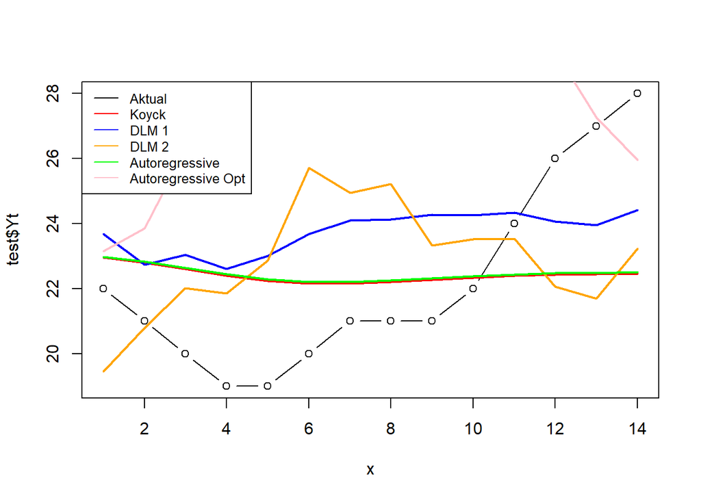

```r
x <- 1:length(test$Xt)  # buat x = 1,2,3,...,7

plot(x, test$Yt, type="b", col="black",
     ylim=range(c(test$Yt, fore.koyck$forecasts,
                  fore.dlm$forecasts, fore.dlm2$forecasts,
                  fore.ardl$forecasts)))

lines(x, fore.koyck$forecasts, col="red", lwd=2)
lines(x, fore.dlm$forecasts, col="blue", lwd=2)
lines(x, fore.dlm2$forecasts, col="orange", lwd=2)
lines(x, fore.ardl$forecasts, col="green", lwd=2)
lines(x, fore.ardl.opt$forecasts, col="pink", lwd=2)

legend("topleft",
       c("Aktual", "Koyck","DLM 1","DLM 2", "Autoregressive", "Autoregressive Opt"),
       lty=1, col=c("black","red","blue","orange","green", "pink"), cex=0.8)
```